# MMPH6117 Assignment 2

Effectiveness of early administration of oseltamivir to patients with H1N1 pdm

Name: Mingze Gao

UID: 3035426241

An observation study of 1,600 patients infected by pandemic H1N1 who are admitted to ICU was conducted to investigate the effectiveness of early administration of oseltamivir within 48 hours. The dataset ‘H1N1pdm.csv’ stored the following variables related to the timing of treatment and mortality:  
(1) Agegp indicates age group (1 = children, 2 = adult, 3 = elderly)  
(2) Males were recorded with male = 1  
(3) Co-morbid conditions: asthma, copd  
(4) mv = 1 indicates mechanical ventilation is needed for the patient on admission  
(5) et = 1 indicates early treatment of oseltamivir within 48 hours  
(6) death = 1 indicates patients ultimately died of pdm H1N1

```r
library(readr)
H1N1 <- read_csv("../Data/CMED6020 Assignment2 - H1N1pdm.CSV")
```

1. Calculate the crude mortality rates of patients receiving early and late oseltamivir treatment respectively. [2 marks]

```r
with(H1N1, table(et, death), 1)
```

```
##    death
## et     0    1
##   0 1155   72
##   1  352   21
```

```r
round(with(H1N1, prop.table(table(et, death), 1)), 3)
```

```
##    death
## et      0     1
##   0 0.941 0.059
##   1 0.944 0.056
```

```r
with(H1N1, t.test(death ~ et))
```

```
##
##  Welch Two Sample t-test
##
## data:  death by et
## t = 0.17359, df = 624.85, p-value = 0.8622
## alternative hypothesis: true difference in means is not equal to 0
## 95 percent confidence interval:
##  -0.02453767  0.02929654
## sample estimates:
## mean in group 0 mean in group 1
##      0.05867971      0.05630027
```

Treatment: 5.6% | Control: 5.9%  
Estimated treatment effect = 0.3%, 95% CI (-2.4%, 2.9%)

2. Describe the patient characteristics across the two treatment groups. [3 marks]

```r
library(ggplot2)
H1N1$et <- as.factor(H1N1$et)
with(H1N1, table(agegp, et), 1)
```

```
##      et
## agegp   0   1
##     1 336  54
##     2 257  35
##     3 634 284
```

```r
with(H1N1, table(male, et), 1)
```

```
##     et
## male   0   1
##    0 613 190
##    1 614 183
```

```r
with(H1N1, table(mv, et), 1)
```

```
##    et
## mv    0   1
##   0 786 194
##   1 441 179
```

```r
with(H1N1, table(asthma, et), 1)
```

```
##       et
## asthma    0    1
##      0 1041  308
##      1  186   65
```

```r
with(H1N1, table(copd, et), 1)
```

```
##     et
## copd    0    1
##    0 1024  271
##    1  203  102
```

3. Estimate the propensity score of receiving early oseltamivir treatment by including all available predictors as main effects in a logistic regression model. Comment on the main characteristics of patients receiving early treatment. [4 marks]

```r
model <- glm(et ~ agegp + male + mv + asthma + copd, data = H1N1, family = binomial(link = "logit"))
model
```

```
##
## Call:  glm(formula = et ~ agegp + male + mv + asthma + copd, family = binomial(link = "logit"),
##     data = H1N1)
##
## Coefficients:
## (Intercept)        agegp         male           mv       asthma
##    -3.08897      0.61910     -0.03752      0.49895      0.26914
##        copd
##     0.69521
##
## Degrees of Freedom: 1599 Total (i.e. Null);  1594 Residual
## Null Deviance:       1738
## Residual Deviance: 1636  AIC: 1648
```

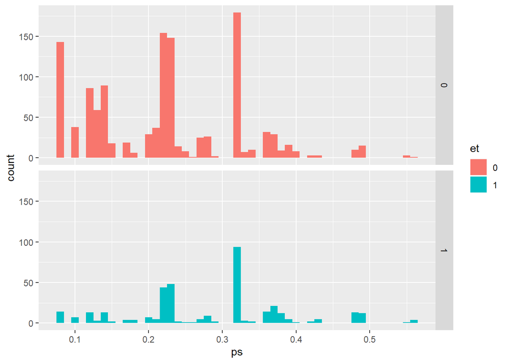

```r
H1N1$ps <- predict(model, type = "response")
ggplot(H1N1, aes(x = ps, fill = et)) +
  geom_histogram(binwidth = 0.01) +
  facet_grid(et ~ .)
```

Based on the results, the main charactesristics of patients receiving the treatments should be agegp and copd, followed by mv as they have higher coefficients.  
For the propensity score, the common support in the range is 0.05 - 0.6.

4. Propensity score stratification (by propensity score quintiles) will be used to analyze the effect of early treatment. Quote the propensity score quintiles. [2 marks]

```r
ps.boundary <- quantile(H1N1$ps, 0:5 / 5)
ps.boundary
```

```
##         0%        20%        40%        60%        80%       100%
## 0.07534144 0.13143860 0.21939379 0.22588661 0.32459441 0.55764654
```

```r
H1N1$psq <- cut(H1N1$ps, ps.boundary, right = F, include.lowest = T, labels = 1:5)
```

5. Assess the balance of the patient characteristics and sample size across treatment groups by propensity score strata (Note: as the dataset have mainly categorical variables, this may limit the possibility of balancing of all variables). Propose any potential way to improve the balance? [4 marks]

```r
df <- data.frame(matrix(nrow = 6, ncol = 2))
colnames(df) <- c('Unadjusted', 'Adjusted')
rownames(df) <- c('Agegp', 'Male', 'Asthma', 'Copd', 'Mv', 'Sample Size')

lmu <- summary(lm(agegp~et, data=H1N1))
lma <- summary(lm(agegp~et+psq, data=H1N1))
df['Agegp', 'Unadjusted'] <- lmu[['coefficients']][2, 3]
df['Agegp', 'Adjusted'] <- lma[['coefficients']][2, 3]

lmu <- summary(lm(male~et, data=H1N1))
lma <- summary(lm(male~et+psq, data=H1N1))
df['Male', 'Unadjusted'] <- lmu[['coefficients']][2, 3]
df['Male', 'Adjusted'] <- lma[['coefficients']][2, 3]

lmu <- summary(lm(asthma~et, data=H1N1))
lma <- summary(lm(asthma~et+psq, data=H1N1))
df['Asthma', 'Unadjusted'] <- lmu[['coefficients']][2, 3]
df['Asthma', 'Adjusted'] <- lma[['coefficients']][2, 3]

lmu <- summary(lm(copd~et, data=H1N1))
lma <- summary(lm(copd~et+psq, data=H1N1))
df['Copd', 'Unadjusted'] <- lmu[['coefficients']][2, 3]
df['Copd', 'Adjusted'] <- lma[['coefficients']][2, 3]

lmu <- summary(lm(mv~et, data=H1N1))
lma <- summary(lm(mv~et+psq, data=H1N1))
df['Mv', 'Unadjusted'] <- lmu[['coefficients']][2, 3]
df['Mv', 'Adjusted'] <- lma[['coefficients']][2, 3]

ss <- read_csv('ss.csv')
sspsq <- read_csv('sspsq.csv')
lmu <- summary(lm(ss~et, data=ss))
lma <- summary(lm(ss~et+psq, data=sspsq))
df['Sample Size', 'Unadjusted'] <- lmu[['coefficients']][2, 3]
df['Sample Size', 'Adjusted'] <- lma[['coefficients']][2, 3]

df
```

|  | Unadjusted | Adjusted |
| --- | --- | --- |
| Agegp | 7.6404800 | 0.6171561 |
| Male | -0.3309898 | 1.3229674 |
| Asthma | 1.0541238 | 0.6457945 |
| Copd | 4.6796899 | 1.6150459 |
| Mv | 4.2029753 | 1.9493607 |
| Sample Size | NaN | -5.0469852 |

Ageap, asthma, copd and mv are much more balanced in the PS strata, whilst for male and sample size, it’s hard to tell. Might assess balance by mean standardized difference?

6. Calculate the stratum-specific and overall effect of early treatment (simple mean of the 5 strata). Please also provide the 95% CI for the overall treatment effect. [4 marks]

```r
means <- aggregate(death ~ et + psq, data = H1N1, FUN = mean)
counts <- aggregate(death ~ et + psq, data = H1N1, FUN = length)
cbind(means, counts$death)
```

| et | psq | death | counts$death |
| --- | --- | --- | --- |
| 0 | 1 | 0.03370787 | 267 |
| 1 | 1 | 0.02941176 | 34 |
| 0 | 2 | 0.06513410 | 261 |
| 1 | 2 | 0.00000000 | 41 |
| 0 | 3 | 0.04666667 | 150 |
| 1 | 3 | 0.02439024 | 41 |
| 0 | 4 | 0.06129032 | 310 |
| 1 | 4 | 0.07627119 | 118 |
| 0 | 5 | 0.08368201 | 239 |
| 1 | 5 | 0.07194245 | 139 |

```r
n <- as.numeric(table(H1N1$psq))
n
```

```
## [1] 301 302 191 428 378
```

```r
overmean <- sum((means$death[means$et == 1] - means$death[means$et == 0]) * n) / sum(n)
overmean
```

```
## [1] -0.0145276
```

```r
vars <- aggregate(death ~ et + psq, data = H1N1, FUN = var)
cbind(vars, counts$death)
```

| et | psq | death | counts$death |
| --- | --- | --- | --- |
| 0 | 1 | 0.03269409 | 267 |
| 1 | 1 | 0.02941176 | 34 |
| 0 | 2 | 0.06112585 | 261 |
| 1 | 2 | 0.00000000 | 41 |
| 0 | 3 | 0.04478747 | 150 |
| 1 | 3 | 0.02439024 | 41 |
| 0 | 4 | 0.05772001 | 310 |
| 1 | 4 | 0.07105606 | 118 |
| 0 | 5 | 0.07700151 | 239 |
| 1 | 5 | 0.06725055 | 139 |

```r
overvar <- sum((vars$death / counts$death) * rep(n, each = 2) ^ 2) / sum(n) ^ 2
overvar
```

```
## [1] 0.0001574231
```

```r
print(paste("95% CI: ", "(", overmean - 1.96 * sqrt(overvar) / 40, ", ", overmean + 1.96 * sqrt(overvar) / 40, ")"))
```

```
## [1] "95% CI:  ( -0.0151423985764758 ,  -0.0139128087963839 )"
```

7. Estimate the overall treatment effect using conditional logistic regression. [3 marks]

```r
library(survival)
clr <- clogit(death ~ et + agegp + male + asthma + copd + mv + strata(psq), data = H1N1)
summary(clr)
```

```
## Call:
## coxph(formula = Surv(rep(1, 1600L), death) ~ et + agegp + male +
##     asthma + copd + mv + strata(psq), data = H1N1, method = "exact")
##
##   n= 1600, number of events= 93
##
##           coef exp(coef) se(coef)      z Pr(>|z|)
## et1    -0.2176    0.8045   0.2644 -0.823    0.411
## agegp  -0.1456    0.8645   0.4706 -0.309    0.757
## male    0.4133    1.5118   0.2548  1.622    0.105
## asthma  0.4287    1.5353   0.2913  1.472    0.141
## copd   -0.2933    0.7458   0.4492 -0.653    0.514
## mv      0.3159    1.3715   0.2974  1.062    0.288
##
##        exp(coef) exp(-coef) lower .95 upper .95
## et1       0.8045     1.2431    0.4791     1.351
## agegp     0.8645     1.1568    0.3437     2.174
## male      1.5118     0.6615    0.9175     2.491
## asthma    1.5353     0.6513    0.8675     2.717
## copd      0.7458     1.3409    0.3092     1.799
## mv        1.3715     0.7291    0.7656     2.457
##
## Concordance= 0.613  (se = 0.027 )
## Likelihood ratio test= 10.71  on 6 df,   p=0.1
## Wald test            = 10.78  on 6 df,   p=0.1
## Score (logrank) test = 11.02  on 6 df,   p=0.09
```

8. Based on the above results, comment on the effectiveness of early treatment of oseltamivir in reducing mortality and validity of the results in terms of control for confounders. [3 marks]